# Homework 1

by: Emily

## Problem 1

```r
#reading in data
AutoData=read.csv('/Users/admin/Documents/Csvv/Auto.csv',header=TRUE)
```

```r
#looking at the type of data we have for each variable
lapply(AutoData, class)
```

```
## $mpg
## [1] "numeric"
##
## $cylinders
## [1] "integer"
##
## $displacement
## [1] "numeric"
##
## $horsepower
## [1] "character"
##
## $weight
## [1] "integer"
##
## $acceleration
## [1] "numeric"
##
## $year
## [1] "integer"
##
## $origin
## [1] "integer"
##
## $name
## [1] "character"
```

The data set has Horsepower characterized as a char because of the “?”, so we convert it to numeric and omit the NAs.

```r
#Converting into Numeric to get NAs and subsetting No Na data
AutoData$horsepower=as.numeric(AutoData$horsepower)
AutoNew=na.omit(AutoData)
```

AutoNew is the modified data set we will be using.

**(a)**

```r
#attaching new data
attach(AutoNew)
lapply(AutoNew,class)
```

```
## $mpg
## [1] "numeric"
##
## $cylinders
## [1] "integer"
##
## $displacement
## [1] "numeric"
##
## $horsepower
## [1] "numeric"
##
## $weight
## [1] "integer"
##
## $acceleration
## [1] "numeric"
##
## $year
## [1] "integer"
##
## $origin
## [1] "integer"
##
## $name
## [1] "character"
```

Quantitative predictors include mpg,displacement,horsepower, weight, year, and origin. Qualitative includes the name of the Auto, and cylinders.

**(b)**

```r
# Finding range for each variable
range(mpg)
```

```
## [1]  9.0 46.6
```

```r
range(displacement)
```

```
## [1]  68 455
```

```r
range(horsepower)
```

```
## [1]  46 230
```

```r
range(weight)
```

```
## [1] 1613 5140
```

```r
range(acceleration)
```

```
## [1]  8.0 24.8
```

```r
range(year)
```

```
## [1] 70 82
```

```r
range(origin)
```

```
## [1] 1 3
```

**(c)**

```
## The mean for mpg is 23.44592  and the sd is 7.805007
```

```
## The mean for displacement is 194.412  and the sd is 104.644
```

```
## The mean for horsepower is 104.4694  and the sd is 38.49116
```

```
## The mean for weight is 2977.584  and the sd is 849.4026
```

```
## The mean for acceleration is 15.54133  and the sd is 2.758864
```

```
## The mean for year is 75.97959  and the sd is 3.683737
```

```
## The mean for origin is 1.576531  and the sd is 0.8055182
```

**(d)**

```r
#removing rows as wanted from textbook
RemoveRowsData=AutoNew[-c(10:84),]
```

```
## The mean for mpg is 24.36845 , the sd is 7.880898 and the range is 11 46.6
```

```
## The mean for displacement is 187.7539 , the sd is 99.93949 and the range is 68 455
```

```
## The mean for horsepower is 100.9558 , the sd is 35.89557 and the range is 46 230
```

```
## The mean for weight is 2939.644 , the sd is 812.6496 and the range is 1649 4997
```

```
## The mean for acceleration is 15.7183 , the sd is 2.693813 and the range is 8.5 24.8
```

```
## The mean for year is 77.13249 , the sd is 3.110026 and the range is 70 82
```

```
## The mean for origin is 1.599369 , the sd is 0.8193079 and the range is 1 3
```

**(e)**

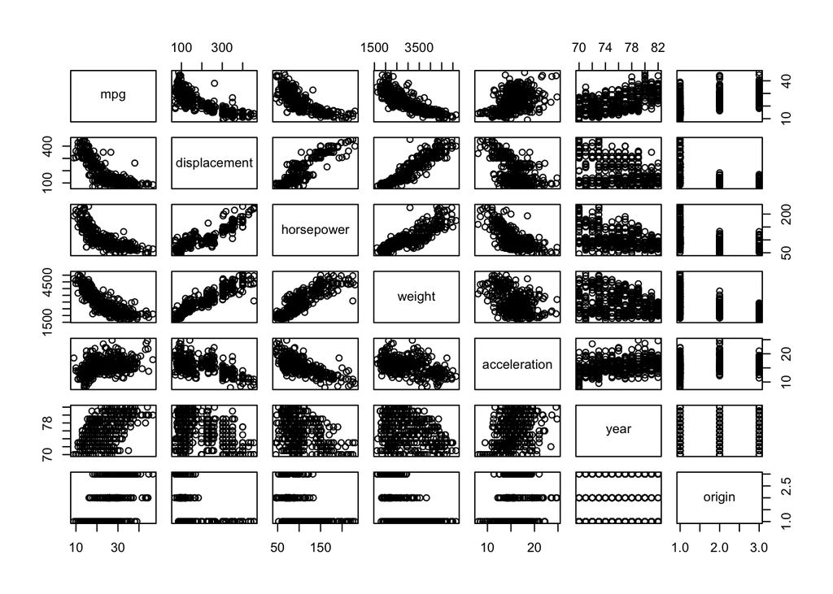

```r
#Pairs plot
pairs(~mpg+displacement+horsepower+weight+acceleration+year+origin, data=AutoNew)
```

There is positive linear correlation among some of the predictors such as displacement and horsepower, horsepower and weight, and lastly displacement and weight.

**(f)** There appears to be multiple predictors that seem to have a negative correlation with mpg such as displacement, horsepower and weight. It could be possible to predict mpg with those variables.

## Problem 2

```r
#loading in data
Parasite=read.table('/Users/admin/Documents/Csvv/CodParasite.txt',header=TRUE)
```

```r
#preforming log transformation on 2nd column
Parasite$Intensity=Parasite[,2]+1
Parasite$Intensity=log(Parasite[,2])
```

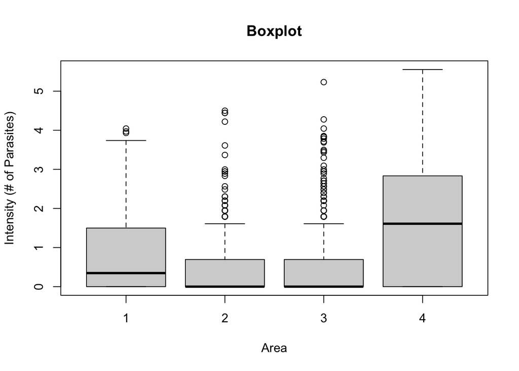

```r
#creating function to make boxplots
BP=function(C1,C2,strC2){
  str=as.character(strC2)
  boxplot(C1~C2,data=Parasite,xlab= str,ylab="Intensity (# of Parasites)",main="Boxplot")
}

BP(Parasite$Intensity,Parasite$Area,"Area")
```

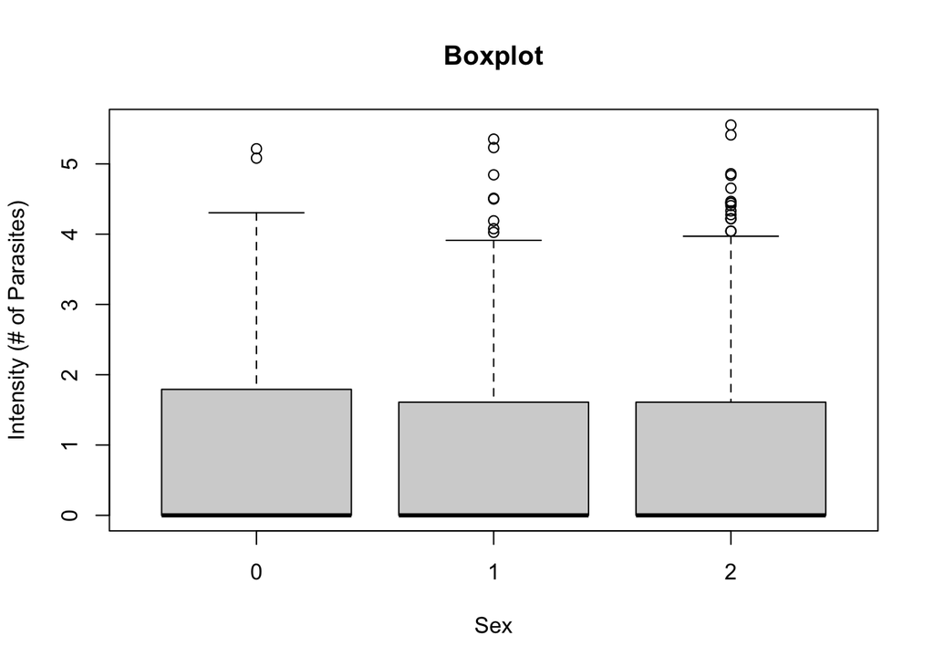

```r
BP(Parasite$Intensity,Parasite$Sex,"Sex")
```

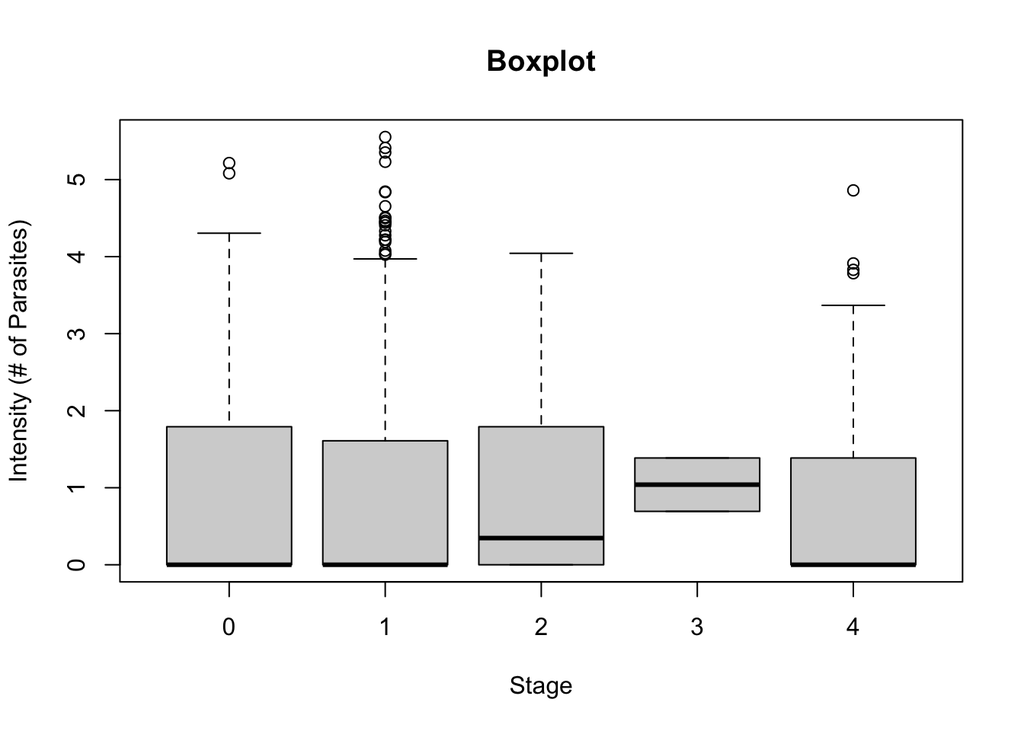

```r
BP(Parasite$Intensity,Parasite$Stage,"Stage")
```

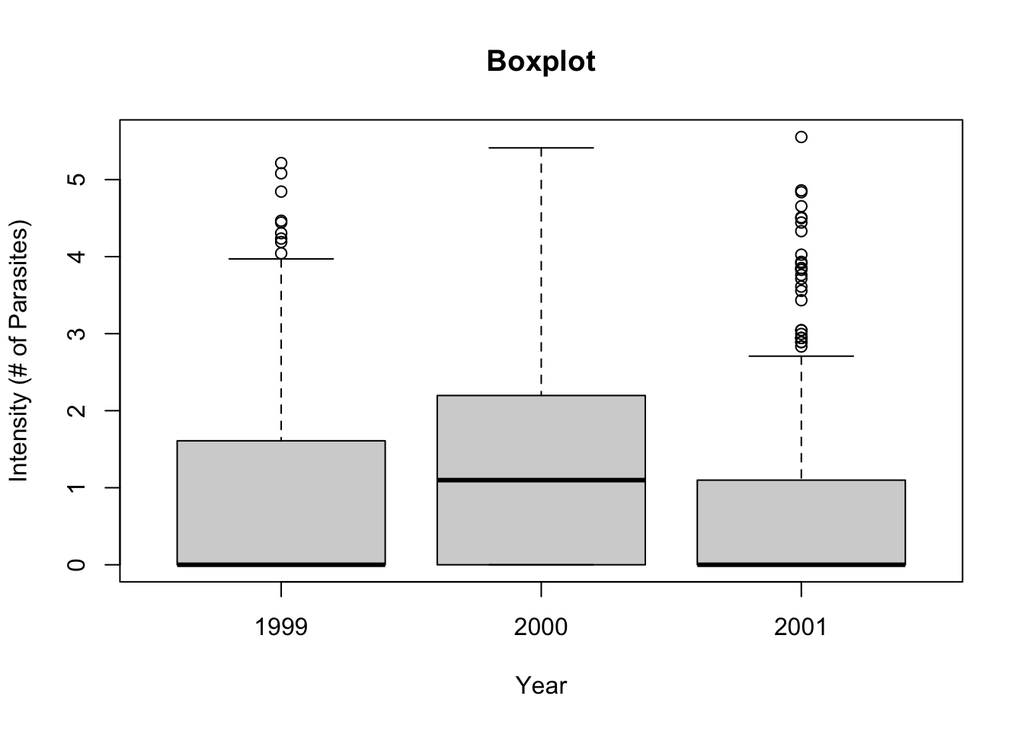

```r
BP(Parasite$Intensity,Parasite$Year,"Year")
```

The box plot of Area shows the most association to intensity compared to the other variables. According to the plot most of the data in the different areas from 1 to 3 are skewed and have possible multiple outliers. Area 4 shows an increase in median, since the data is more spread out. The plots do have overlap but some are longer than others.

The box plot for years also seems to have a bit of an association with intensity as the year 2000 seems to have have increased, then in 2001 the median fell.

## Problem 3

```r
#loading in data
Owls=read.table('/Users/admin/Documents/Csvv/Owls.txt',header=TRUE)
```

**(a)**

```r
#Factoring categorical variables
Owls$SexParent=as.factor(Owls$SexParent)
Owls$FoodTreatment=as.factor(Owls$FoodTreatment)
```

```r
#attaching data
attach(Owls)
sapply(Owls,class)
```

```
##               Nest      FoodTreatment          SexParent        ArrivalTime
##        "character"           "factor"           "factor"          "numeric"
## SiblingNegotiation          BroodSize        NegPerChick
##          "integer"          "integer"          "numeric"
```

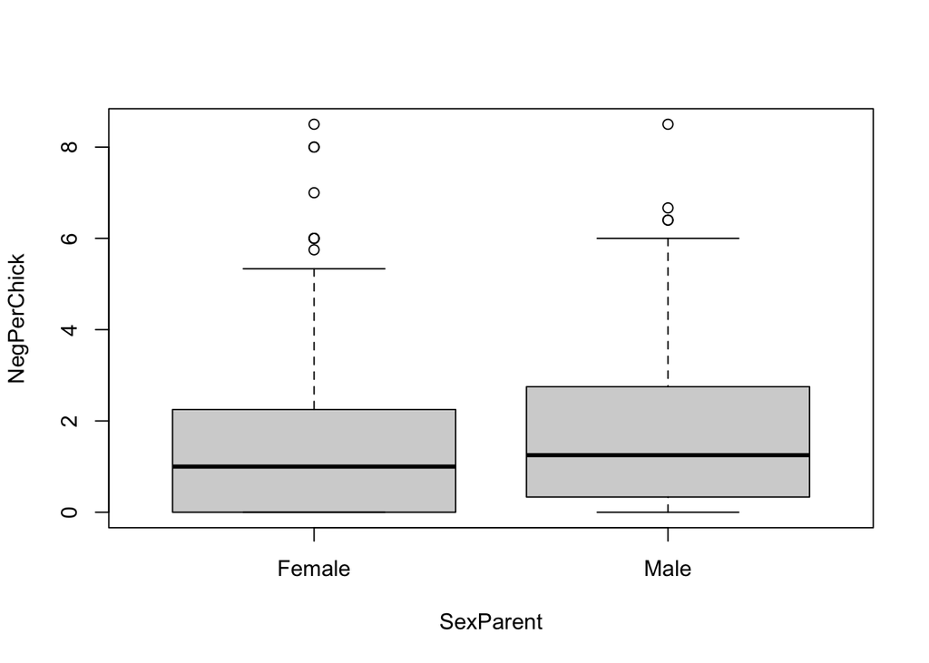

```r
#creating boxplots
boxplot(NegPerChick~SexParent)
```

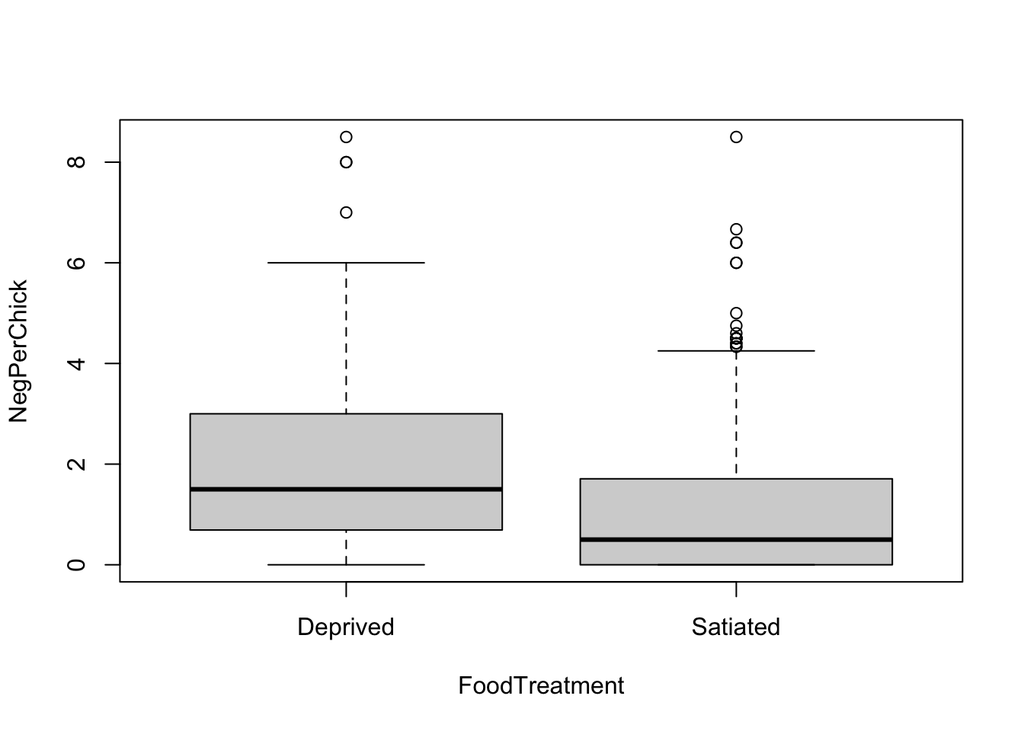

```r
boxplot(NegPerChick~FoodTreatment)
```

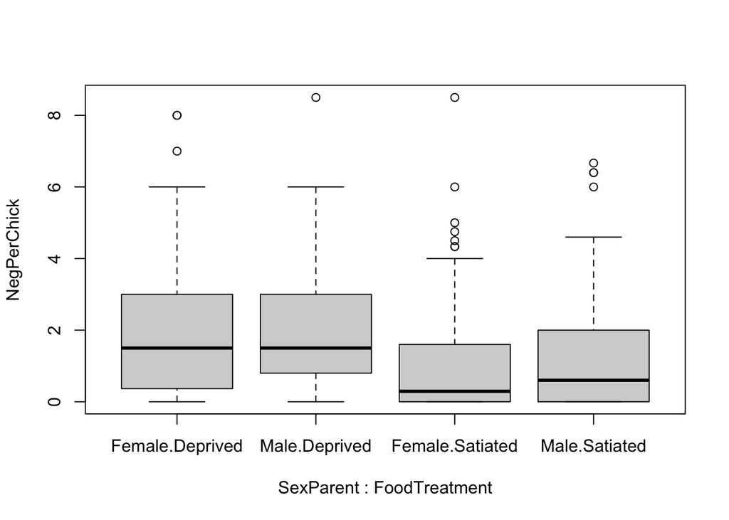

```r
boxplot(NegPerChick~SexParent+FoodTreatment+FoodTreatment*SexParent,data=Owls)
```

**(b)**

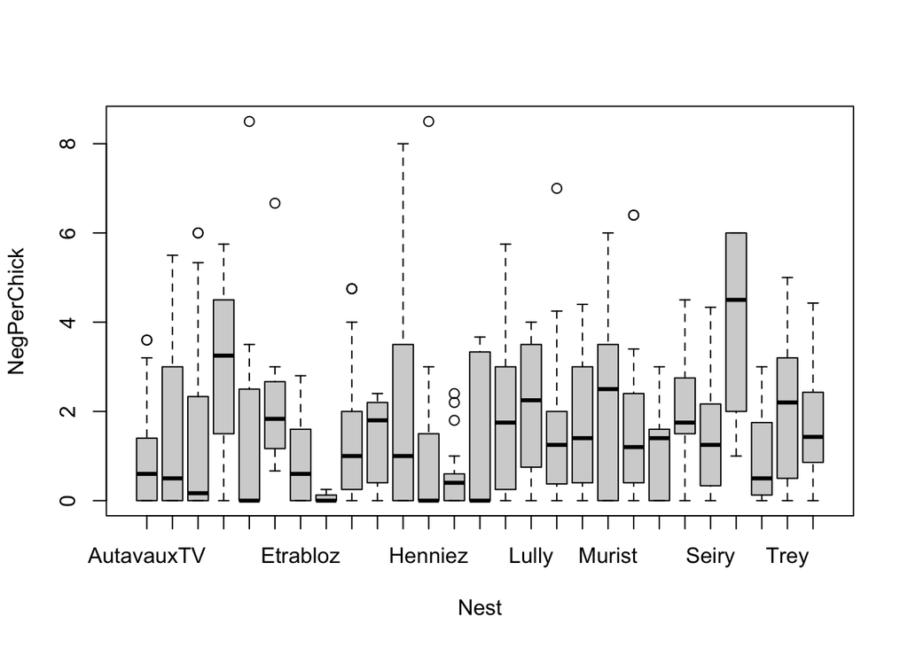

```r
boxplot(NegPerChick~Nest)
```

There are differences for Neg per chick across the various nesting sites.

**(c)**

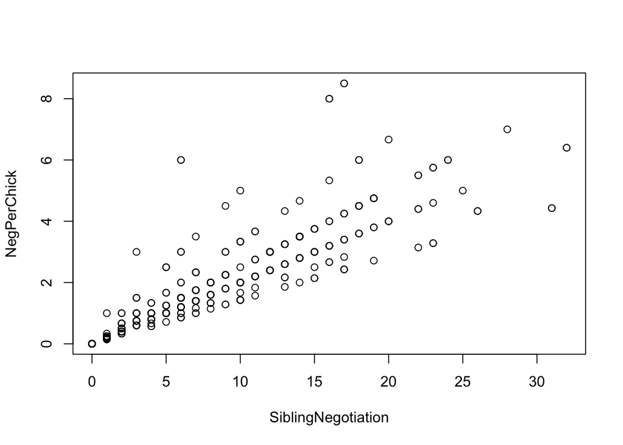

```r
plot(NegPerChick~SiblingNegotiation)
```

Yes,there is an association between these features as it seems like negperchick increases as sibling negation increases.

**(d)**

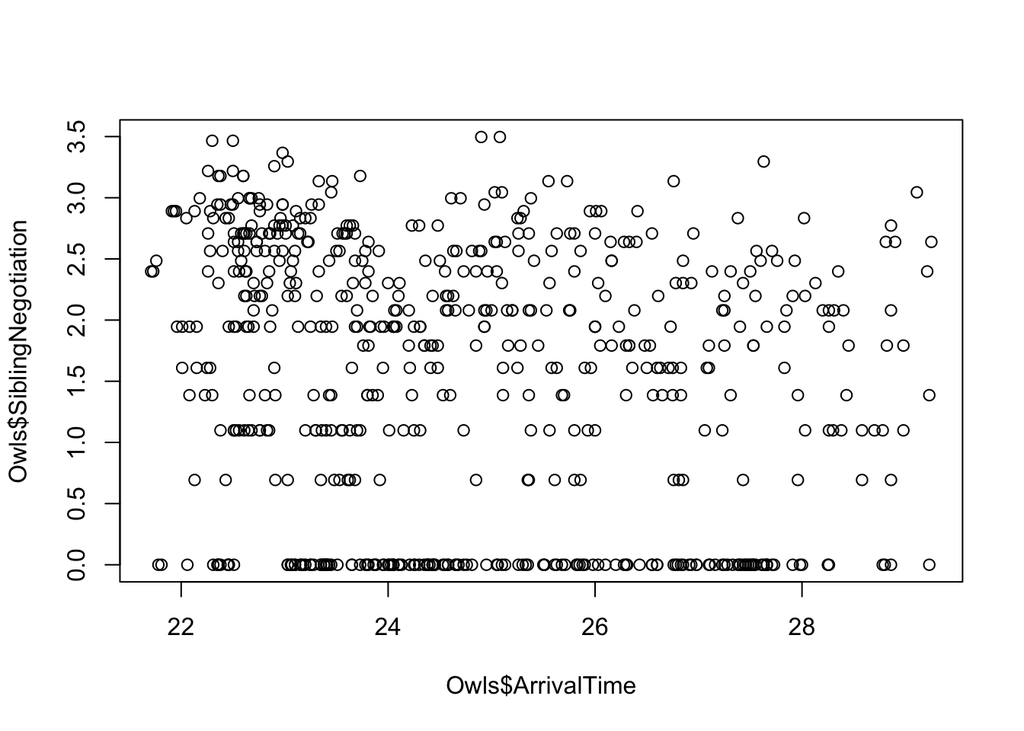

```r
#Log transformation for graphing purposes
Owls$SiblingNegotiation=Owls[,5]+1
Owls$SiblingNegotiation=log(Owls[,5])
plot(Owls$SiblingNegotiation~Owls$ArrivalTime)
```